# LSA Assignment - 1

David Wheatley - 01633983

# 1 - Introduction

The objective of this assignment is to forecast daily demand for the next two weeks (from 06/16/2015 to 06/29/2015) to help the managers make inventory replenishment decisions. The scope of this assignment is limited to the ingredient “lettuce” and for a single store “ID:46673”

The assignment is broken into 6 main sections:

- Modeling historic consumption
- Investigation of the time series
- Building a Holt-Winters model
- Building an ARIMA model
- Evaluation of model performance
- Improving forecast accuracy

# 2 - Modelling historic consumption

The data provided is spread across 11 tables which need to be joined, summarised and filtered as appropriate to provide the required output. In this section a three stage process to prepare the required daily lettuce consumption data is detailed:

- Create a bill of materials, defining the quantity of lettuce in each recipe.
- Summarize the daily orders.
- Combine to calculate daily lettuce consumption.

### 2.1 - Creating a bill of materials

From the ingredients table we know the the ingredient of interest is Lettuce. $(ID=27)$.

Item $(ID=291)$ is also checked to confirm there are no lettuce consumed using a metric units.

```r
ingredient <- 27
# We also check ingredient 291 to confirm there are no metric values
# ingredient <- 291
```

Lettuce can be contained at both the recipe and sub-recipe level.

The following code block checks the lettuce content at the recipe level.

This reveals that a total of 34 recipes include lettuce, for which the quantities vary (including 4 for which quantity=0).

```r
# Load the data set "recipe_ingredient_assignments" file
recipe_ingredient_assignments <- read.csv('recipe_ingredient_assignments.csv',header = TRUE)

# Filter to only show lettuce
recipe <- filter(recipe_ingredient_assignments,IngredientId==ingredient)

# Drop the "IngredientId" column and re-title the columns
recipe <- select(recipe, RecipeId, Quantity)
colnames(recipe) <- c("RecipeId", "Amount_per_item")

# Display the data table
recipe
```

| RecipeId | Amount_per_item |
| --- | --- |
| 687 | 0 |
| 688 | 0 |
| 689 | 0 |
| 690 | 0 |
| 959 | 12 |
| 960 | 24 |
| 1044 | 10 |
| 1220 | 5 |
| 1778 | 5 |
| 1815 | 1 |

[output cut: 24 more lines]

The same process is then used to identify all the sub-recipes that contain lettuce, along with the associated quantities. This reveals a further 7 sub-recipes contain lettuce.

```r
# Load the dataset "sub_recipe_ingr_assignments" file
sub_recipe_ingr_assignments <- read.csv('sub_recipe_ingr_assignments.csv',header = TRUE)

# Filter to only show lettuce
sub_recipe <- filter(sub_recipe_ingr_assignments, IngredientId==ingredient)

# Display the datatable
sub_recipe
```

| SubRecipeId | IngredientId | Quantity |
| --- | --- | --- |
| 5 | 27 | 4 |
| 10 | 27 | 2 |
| 49 | 27 | 2 |
| 50 | 27 | 0 |
| 51 | 27 | 2 |
| 58 | 27 | 4 |
| 73 | 27 | 2 |

The next step is to use the “recipe_sub_recipe_assignments” file to find which recipes contain the identified sub-recipes.

```r
# Load the dataset "recipe_sub_recipe_assignments" file
recipe_sub_recipe_assignments <- read.csv('recipe_sub_recipe_assignments.csv',header = TRUE)

# Perform the join using "SubRecipeId"
j.sub_recipe <- left_join(recipe_sub_recipe_assignments, sub_recipe, by = c("SubRecipeId"="SubRecipeId"))

# Display the table
j.sub_recipe
```

| RecipeId | SubRecipeId | Factor | IngredientId | Quantity |
| --- | --- | --- | --- | --- |
| 2 | 3 | 1 | NA | NA |
| 2 | 9 | 1 | NA | NA |
| 2 | 10 | 1 | 27 | 2 |
| 2 | 12 | 1 | NA | NA |
| 6 | 1 | 1 | NA | NA |
| 6 | 9 | 1 | NA | NA |
| 6 | 10 | 1 | 27 | 2 |
| 6 | 12 | 1 | NA | NA |
| 7 | 9 | 1 | NA | NA |
| 7 | 10 | 1 | 27 | 2 |

[output cut: 9990 more lines]

Here it is noted that a recipe may have lettuce content derived from multiple sub-recipes (eg.recipe 9 contains sub-recipes 5 and 10).

After performing some data cleaning / preparation the table is combined with the recipe table and a group_by function used to summarise the total content per recipe.

```r
# Prepare the sub_recipe information
qty_in_sub <- j.sub_recipe %>%
  mutate(Total = Quantity*Factor) %>% # Calculate the amount of lettuce in each RecipeId
  drop_na() %>%                       # Remove the rows without any lettuce
  select(RecipeId, Total)             # Drop the columns no longer required

# Change the column names to make them more meaningful
colnames(qty_in_sub) <- c("RecipeId", "Amount_per_item")

# Bind the 2 tables (recipe and sub-recipes) together to create a single table
BOM <- rbind(recipe,qty_in_sub)

# And group the information summing the values to generate a single quantity per recipe
BOM <- BOM %>% group_by(RecipeId) %>% summarise(qty_per_item = sum(Amount_per_item), .groups = 'drop')

# Display the data table
BOM
```

| RecipeId | qty_per_item |
| --- | --- |
| 2 | 2 |
| 6 | 2 |
| 7 | 2 |
| 8 | 2 |
| 9 | 6 |
| 10 | 2 |
| 11 | 2 |
| 12 | 2 |
| 13 | 2 |
| 14 | 6 |

[output cut: 2184 more lines]

### 2.2. Summary of orders

Having defined the quantity of lettuce in each recipe, the next stage is to determine the number of each recipe sold.

This information is held in the “menuitem” dataframe however to be able to link to the BOM table the recipeID must first be obtained using the “menu_items” dataframe as detailed in the following code block.

```r
# This data frame contains quantities ordered by menu_item
menuitem <- read.csv('menuitem.csv',header = TRUE)

# This dataframe allows menu id and recipe id to be linked
menu_items <- read.csv('menu_items.csv',header = TRUE)

# Left join the dataframes to allow the number of orders per recipeid to be obtained
orders <- left_join(menuitem, menu_items, by = c("Id"="MenuItemId"))

# Retain only the columns of interest
orders <- select(orders, date, StoreNumber, Quantity,RecipeId)

# Display the table
orders
```

| date | StoreNumber | Quantity | RecipeId |
| --- | --- | --- | --- |
| 15-03-05 | 46673 | 1 | 358 |
| 15-03-05 | 46673 | 1 | 305 |
| 15-03-05 | 12631 | 1 | 47 |
| 15-03-05 | 12631 | 1 | 22 |
| 15-03-05 | 12631 | 1 | 579 |
| 15-03-05 | 46673 | 1 | 12 |
| 15-03-05 | 12631 | 1 | 40 |
| 15-03-05 | 12631 | 1 | 303 |
| 15-03-05 | 12631 | 1 | 67 |
| 15-03-05 | 12631 | 1 | 7 |

[output cut: 9990 more lines]

### 2.3. Calculate daily lettuce consumption.

Now the “RecipeId” has been obtained the orders can be easily linked with the BOM dataframe to calculate the total amount of lettuce per order.

```r
# Left join the data frames on recipe number
orders_qty <- left_join(x=orders, y=BOM, by="RecipeId")

# Calculate the amount of lettuce in each order
orders_qty <- mutate(orders_qty,total = Quantity*qty_per_item)

# Display the dataframe
orders_qty
```

| date | StoreNumber | Quantity | RecipeId | qty_per_item | total |
| --- | --- | --- | --- | --- | --- |
| 15-03-05 | 46673 | 1 | 358 | 2 | 2 |
| 15-03-05 | 46673 | 1 | 305 | NA | NA |
| 15-03-05 | 12631 | 1 | 47 | 2 | 2 |
| 15-03-05 | 12631 | 1 | 22 | 2 | 2 |
| 15-03-05 | 12631 | 1 | 579 | NA | NA |
| 15-03-05 | 46673 | 1 | 12 | 2 | 2 |
| 15-03-05 | 12631 | 1 | 40 | 2 | 2 |
| 15-03-05 | 12631 | 1 | 303 | NA | NA |
| 15-03-05 | 12631 | 1 | 67 | 2 | 2 |
| 15-03-05 | 12631 | 1 | 7 | 2 | 2 |

[output cut: 9990 more lines]

The scope of this assignment is limited to $store = 46673$ so an appropriate filter is applied after which the values are grouped to provide a measure of the total lettuce consumed per day.

To facilitate easy analysis of the other stores, the store ID is set as a variable which can be easily amended.

```r
#Filter the data to only retain the information for the store of interest.
store = 46673
#store = 4904
#store = 12631
#store = 20974

f.orders_qty <- filter(orders_qty,StoreNumber==store)

# Rearrange and drop columns and rows that are no longer required
f.orders_qty <-select(f.orders_qty, date,RecipeId,total) %>% drop_na()

# Convert the dates to a date format
f.orders_qty$date <- as.Date(f.orders_qty$date, "%y-%m-%d")

#Group the results by date
summary <- f.orders_qty %>% group_by(date) %>% summarise(Total = sum(total), .groups = 'drop')

#Display the table
summary
```

| date | Total |
| --- | --- |
| 2015-03-05 | 152 |
| 2015-03-06 | 100 |
| 2015-03-07 | 54 |
| 2015-03-08 | 199 |
| 2015-03-09 | 166 |
| 2015-03-10 | 143 |
| 2015-03-11 | 162 |
| 2015-03-12 | 116 |
| 2015-03-13 | 136 |
| 2015-03-14 | 68 |

[output cut: 93 more lines]

# 3 - Investigation of the time series

### 3.1 Plotting the data

Having obtained the daily consumption of lettuce a plot is produced to facilitate an initial inspection of the data.

Key observations include:

- The presence of seasonality in the plot, corresponding to a weekly cycle.
- Negligible overall trend, illustrated by the red linear line.
- An apparent dip in sales in May followed by a step change in June, illustrated by blue smoothed profile line.

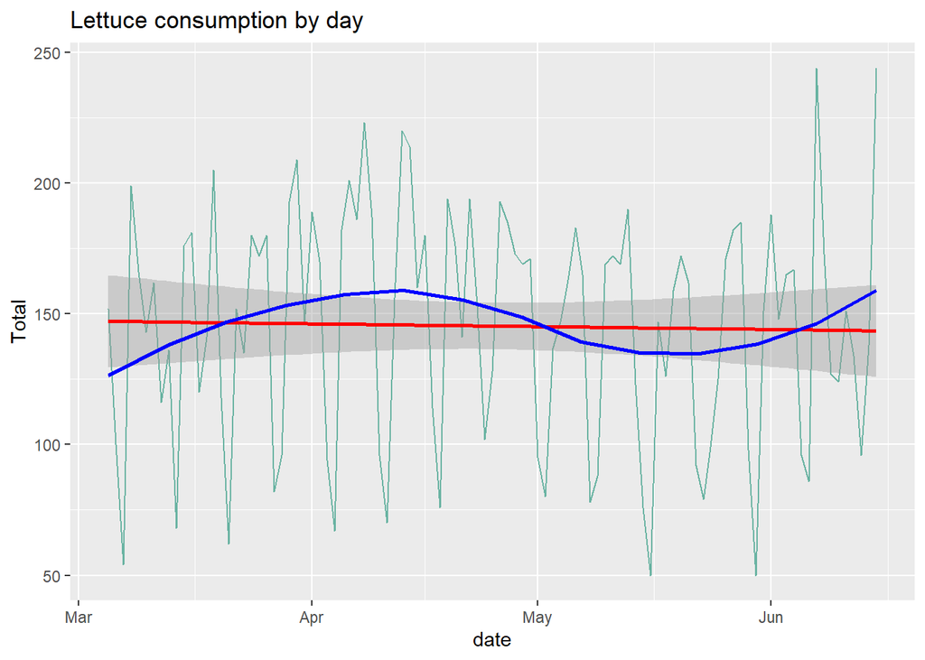

```r
# Plot the time series including a trend line and rolling average
ggplot(summary, aes(x=date, y=Total))+
  ggtitle("Lettuce consumption by day") +
  geom_line(color="#69b3a2") +
  geom_smooth(method = "lm", formula= 'y ~ x', colour ='red')+
  geom_smooth(method = 'loess', formula= 'y ~ x', n = 14,se = FALSE, colour ='blue')
```

### 3.2 Convert the data to a timeseries

In order to process the data it must be first converted into a time series, with frequency set to 7 to correspond with the weekly cycles.

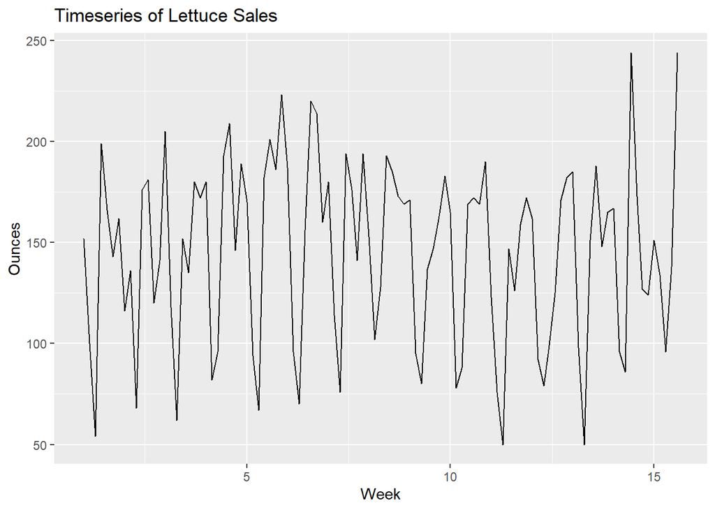

```r
# Convert to a time series setting the frequency to 7 for the number of days in a week
lettuce.ts <- ts(summary[,2])
lettuce.ts <- ts(as.vector(lettuce.ts), frequency = 7)


# Display a plot of the time series 'lettuce'
autoplot(lettuce.ts) +
  ylab('Ounces') +
  xlab('Week') +
  ggtitle('Timeseries of Lettuce Sales')
```

### 3.3 Decomposing timeseries

To investigate the time series further an STL decomposition is performed. Now the seasonality becomes more apparent, along with the overall trend observed earlier.

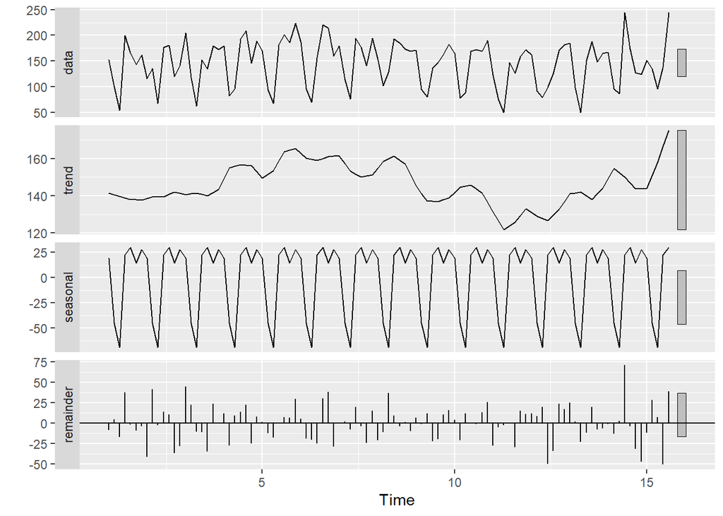

```r
lettuce.ts %>% stl(s.window = "period") %>% autoplot
```

To check if the residuals resemble white noise the Box-Ljung Test is used. If the p-values are large (greater than 0.05) then the residuals can be considered independent.

As expected this is not the case. The steps involved in resolving this are explored in the following sections of this report.

```r
Box.test(lettuce.ts,lag=7, type='Lj')
```

```
##
##  Box-Ljung test
##
## data:  lettuce.ts
## X-squared = 89.469, df = 7, p-value < 2.2e-16
```

# 4 - Building a Holt-Winters model

### 4.1 Building a simple Exponential smoothing model

Before beginning to build a Holts-Winter model a simple exponential smoothing model is created. Given the SES model is incapable of modeling seasonal and trend information the forecast produced resembles a straight line. Furthermore an immediate concern is that both weekly peak demands in June fall outside the 95% confidence interval of the model.

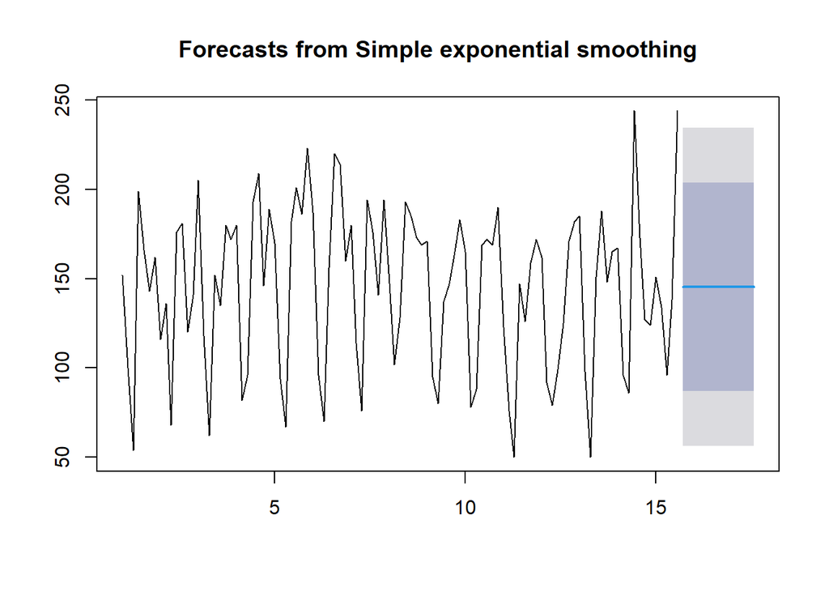

```r
fc <- ses(lettuce.ts,h=14)
plot(ses(lettuce.ts,h=14))
```

The Holt-Winters model expands on this to include parameters to account for seasonality and trend effects. These can be set to either additive(A), multiplicative(M) of none(N) to best fit the series. From the initial analysis performed the expected parameters are:

- Error - Assumed to be additive (A)
- Trend - No significant observed trend (N)
- Seasonality - Given variation is reasonably consistent an additive component should be appropriate (A)

### 4.2 Running the ETS state space model

Setting the model parameters to $'ZZZ'$, allows the function to select the optimum model through minimizing the information criterion.

Inspecting the output below it is observed that a $'MNA'$ model has been selected, with initial state ($l_0$ = 145.6322) and smoothing parameters ($alpha$ = 1e-04 and $gamma$ = 1e-04)

```r
ets(lettuce.ts, model ='ZZZ')
```

```
## ETS(M,N,A)
##
## Call:
##  ets(y = lettuce.ts, model = "ZZZ")
##
##   Smoothing parameters:
##     alpha = 1e-04
##     gamma = 1e-04
##
##   Initial states:
##     l = 145.6322
##     s = 26.823 13.9141 30.6986 24.3151 -66.7508 -45.1285
##            16.1285
##
##   sigma:  0.1898
##
##      AIC     AICc      BIC
## 1163.044 1165.435 1189.391
```

### 4.3 Investigating the parameters selected.

Based on the initial investigation an $'ANA'$ model was expected, however a multiplicative error term was favored by the ETS function giving a $'MNA'$ model. Overlaying the $'MNA'$ and $'ANA'$ models on the same plot shows the differences to be negligible, with seasonality being captured well by both. It is also noted that, as envisaged from the SES model earlier, the series fails to capture the step change in the June data, when predicting future sales this could be problematic.

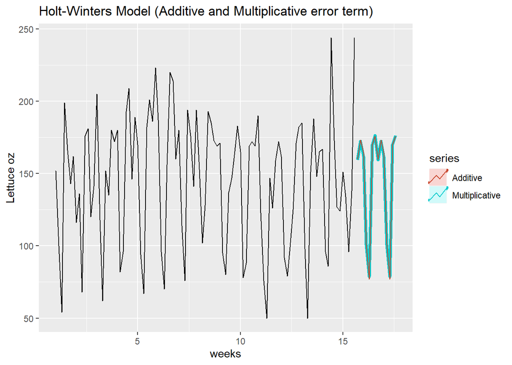

```r
# We can use the holt method to include a trend element
hw1 <- forecast(ets(lettuce.ts, model = "MNA"), h = 14)
hw2 <- forecast(ets(lettuce.ts, model = "ANA"), h = 14)

autoplot(lettuce.ts) +
  ggtitle('Holt-Winters Model (Additive and Multiplicative error term)')+
  xlab('weeks') +
  ylab('Lettuce oz') +
  autolayer(hw1, series='Multiplicative',PI=FALSE,size=1.5) +
  autolayer(hw2, series='Additive',PI=FALSE)
```

### 4.4 Investigating the residuals

The residuals analysis, for the $'MNA'$ model shows a reasonable approximation to a normal distribution, with zero mean and the ACF lag plot largely within the limits of statistical significance, although the p-value from the Ljung-Box test indicates the residuals do not represent white noise. The performance of this model, relative to other ARIMA models, will be evaluated further in section 6.

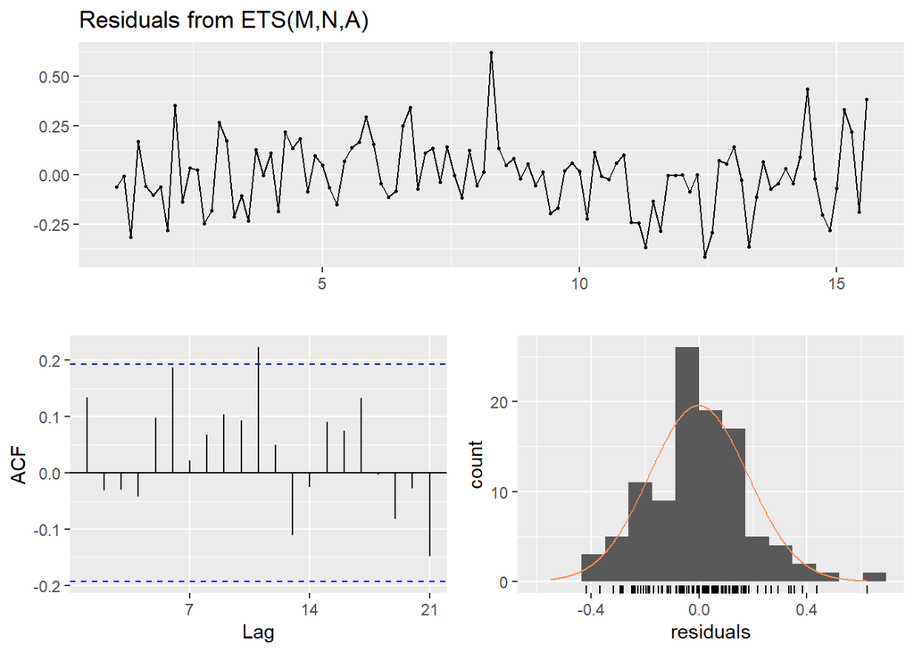

```
##
##  Ljung-Box test
##
## data:  Residuals from ETS(M,N,A)
## Q* = 17.731, df = 5, p-value = 0.003304
##
## Model df: 9.   Total lags used: 14
```

```r
checkresiduals(hw1)
```

# 5 - Fitting an ARIMA Model

To fit an ARIMA model the 3 stage Box-Jenkins procedure is followed:

- Identification (establishing a stationary time series)
- Estimation (optimizing the parameters to fit the ARIMA model)
- Verification (perform residuals analysis)

From the STL decomposition, performed in section 3.3, the model was found to be non-stationary and therefore requires further processing.

### 5.1 Identification

Visual inspection of the original time series showed it to be broadly hetroskedastic, and therefore unnecessary to scale using a log transformation. There is however a small reduction in the variance during May, the significance of which will be investigated later.

A seasonal ARIMA model consists of 7 parameters $(p,d,q)(P,D,Q)[m]$ that define the Auto-Regressive (P/p), Moving Average(Q/q) and Differencing (D/d) components for both the seasonal and non seasonal elements of the model while(m) defines the frequency of the seasonality.

To determine these parameters the inter-temporal correlations need to be investigated using the auto-correlation (ACF) and partial auto-correlations (PACF) plots, shown below.

Firstly looking at the seasonal information it can observed:

- Significant results exist at a lags of multiples of 7, which corresponds to the weekly cycles. $(m=7)$
- PACF cuts off after 1 cycle giving a Auto Regressive component of $(P=1)$
- ACF tails off slowly giving a Moving Average component $(Q=0)$

It is likely that short run non-seasonal components will also contribute to the model. Inspecting the first few lags (less than m) reveals.

- PACF tails off giving $(p=0)$
- ACF remains significant throughout $(q=?)$ given the determination is unclear it has provisionally been set as 0.

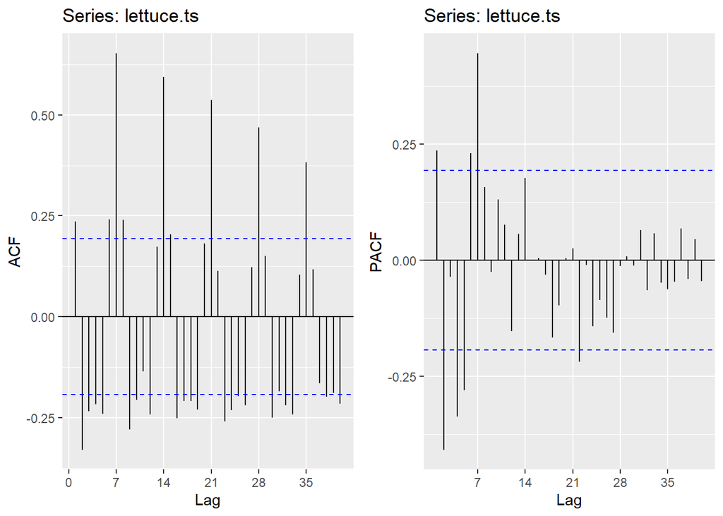

```r
grid.arrange(ggAcf(lettuce.ts, lag.max = 40), ggPacf(lettuce.ts, lag.max = 40), ncol=2)
```

Checking the nsdiffs() reveals applying a 1st order differencing of the seasonal component should provide the required stationarity $(D=1)$

```r
# seasonal stationarity
nsdiffs(lettuce.ts)
```

```
## [1] 1
```

Performing stationarity tests* on the seasonally differenced series confirm that there is no further requirement to de-trend the data $(d=0)$

- noting the null hypothesis for ADF and PP tests are non-stationarity while the null hypothesis for KPSS is stationarity.

```r
# calculate the seasonally differenced series
diff.lettuce.ts <- diff(lettuce.ts, lag = 7, differences =1)

#Perform Stationarity test on de-seasonalised data
adf.test(diff.lettuce.ts)
```

```
##
##  Augmented Dickey-Fuller Test
##
## data:  diff.lettuce.ts
## Dickey-Fuller = -4.6225, Lag order = 4, p-value = 0.01
## alternative hypothesis: stationary
```

```r
pp.test(diff.lettuce.ts)
```

```
##
##  Phillips-Perron Unit Root Test
##
## data:  diff.lettuce.ts
## Dickey-Fuller Z(alpha) = -88.265, Truncation lag parameter = 3, p-value
## = 0.01
## alternative hypothesis: stationary
```

```r
kpss.test(diff.lettuce.ts)
```

```
##
##  KPSS Test for Level Stationarity
##
## data:  diff.lettuce.ts
## KPSS Level = 0.075888, Truncation lag parameter = 3, p-value = 0.1
```

Re-running the STL on the differenced time series also reveals the seasonal element has now been largely eliminated, indicated by the size of the grey bar to the right of the plot.

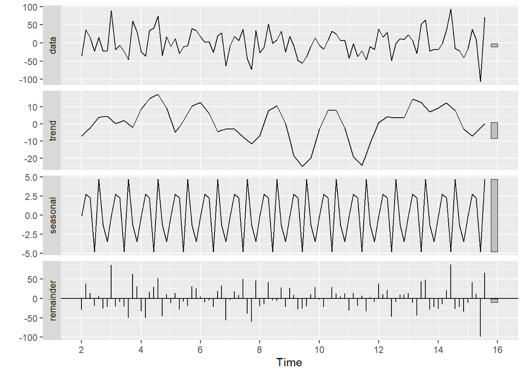

```r
diff.lettuce.ts %>% stl(s.window = "period") %>% autoplot
```

### 5.2 Estimation

Using the auto.arima() function to generate the ARIMA parameters any differences from the proposed $(0,0,0)(1,1,0)[7]$ model can then be investigated.

The main difference observed is the value of $(P)$ selected by the function, which is 2 not 1 as expected. Looking back at the PACF plot the bar on lag 14 is only marginally below the statistically significant threshold and could therefore be considered significant, the impact of this will be evaluated shortly.

The only other discrepancy is the value of $(q)$, for which questions had already been asked. Depending on the information criteria used (BIC or AIC) the selection is either 1 or 0, both will be investigated to understand the respective performance.

```r
#Fit an ARIMA model using AIC information criteria
auto.arima(lettuce.ts,ic='aic')
```

```
## Series: lettuce.ts
## ARIMA(0,0,1)(2,1,0)[7]
##
## Coefficients:
##          ma1     sar1     sar2
##       0.2526  -0.6856  -0.3802
## s.e.  0.1279   0.1118   0.1171
##
## sigma^2 estimated as 881.2:  log likelihood=-462.31
## AIC=932.63   AICc=933.07   BIC=942.89
```

```r
#Fit an ARIMA model using BIC information criteria
auto.arima(lettuce.ts,ic='bic')
```

```
## Series: lettuce.ts
## ARIMA(0,0,0)(2,1,0)[7]
##
## Coefficients:
##          sar1     sar2
##       -0.5887  -0.3022
## s.e.   0.1038   0.1119
##
## sigma^2 estimated as 917.5:  log likelihood=-464.12
## AIC=934.23   AICc=934.49   BIC=941.92
```

Overlaying the plots using AIC and BIC as well as the expected model show they all reflect the seasonality well and are more reflective of the observed step change in June than the ETS model produced earlier.

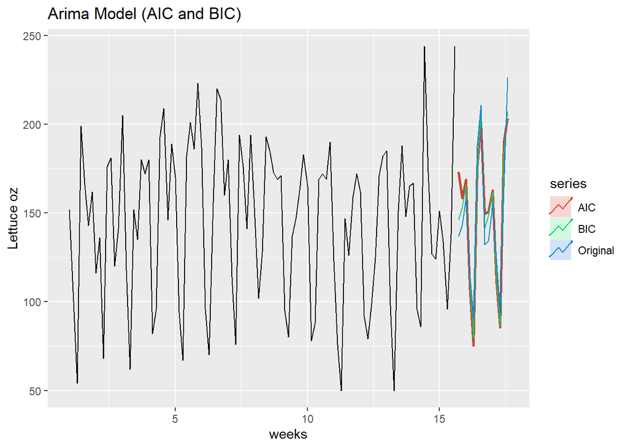

```r
#Create the forecasts
arima.aic <- forecast(auto.arima(lettuce.ts,ic='aic'),h=14)
arima.bic <- forecast(auto.arima(lettuce.ts,ic='bic'),h=14)
arima.orig <- forecast(Arima(lettuce.ts, order= c(0,0,0), seasonal=c(1,1,0)),h=14)

#Plot
autoplot(lettuce.ts) +
  ggtitle('Arima Model (AIC and BIC)')+
  xlab('weeks') +
  ylab('Lettuce oz') +
  autolayer(arima.aic, series='AIC',PI=FALSE,size=1) +
  autolayer(arima.bic, series='BIC',PI=FALSE) +
  autolayer(arima.orig, series='Original',PI=FALSE)
```

### 5.3 Verification

Checking the residuals reveals:

- While the distributions vary between the models all approximate to a normal distribution with zero mean
- In all cases 2 values on the ACF plot are marginally above the significant threshold
- The Ljung-Box test p-value for both the AIC and BIC model are consistent with white noise, while the originally calculated parameter retain some significance in the residuals.
- All models exhibit a spike in the residuals, corresponding with the step change in June values, causing a longer tail on the distribution plots.

Given the above anlysis the functions generated by the auto.arima() function are favored.

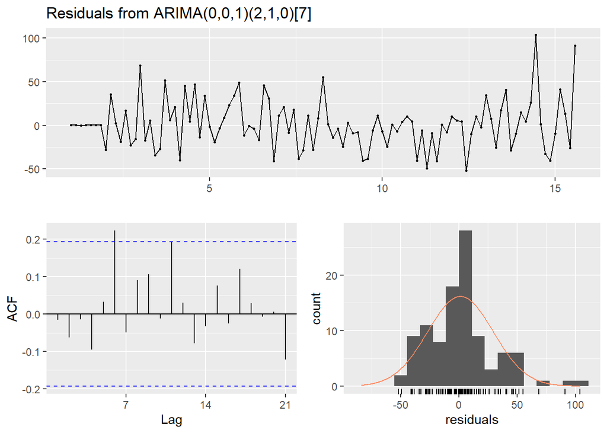

```
##
##  Ljung-Box test
##
## data:  Residuals from ARIMA(0,0,1)(2,1,0)[7]
## Q* = 15.067, df = 11, p-value = 0.1795
##
## Model df: 3.   Total lags used: 14
```

```r
checkresiduals(arima.aic)
```

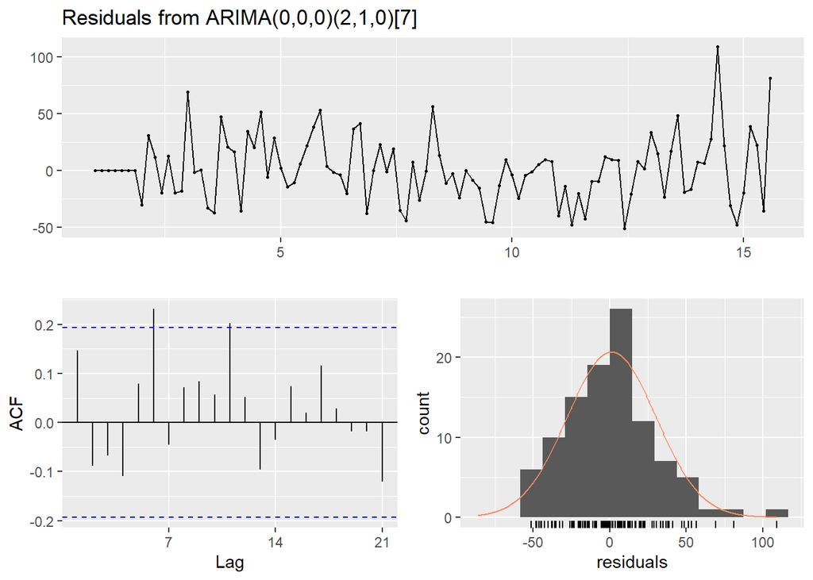

```
##
##  Ljung-Box test
##
## data:  Residuals from ARIMA(0,0,0)(2,1,0)[7]
## Q* = 19.909, df = 12, p-value = 0.06883
##
## Model df: 2.   Total lags used: 14
```

```r
checkresiduals(arima.bic)
```

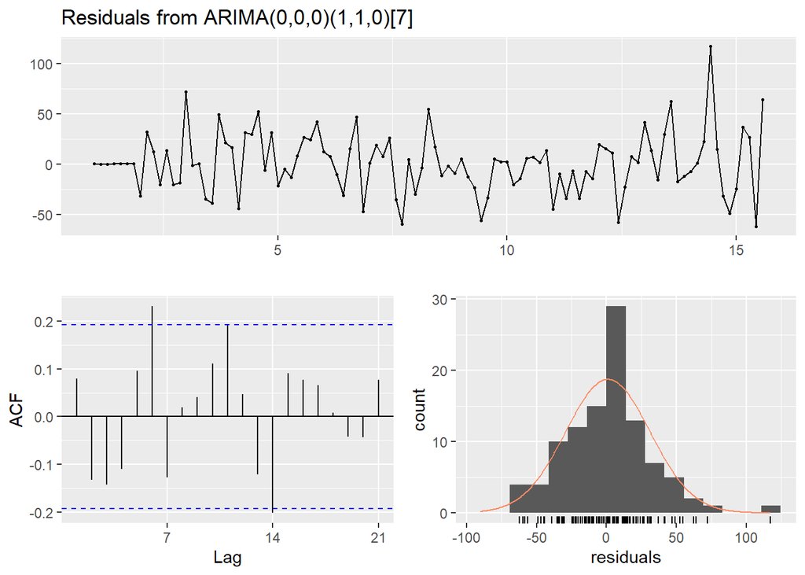

```
##
##  Ljung-Box test
##
## data:  Residuals from ARIMA(0,0,0)(1,1,0)[7]
## Q* = 27.898, df = 13, p-value = 0.009351
##
## Model df: 1.   Total lags used: 14
```

```r
checkresiduals(arima.orig)
```

One possible way to handle the increased variation in June could be to apply a BoxCox transformation. The following code block checks the appropriateness of the transformation, noting that setting lambda to 0 is equivalent of applying a log transform.

```r
#Calculate the BoxCox for the whole timeseries
boxcox <- BoxCox.lambda(lettuce.ts)

#Display the results
print(boxcox)
```

```
## [1] 0.1952829
```

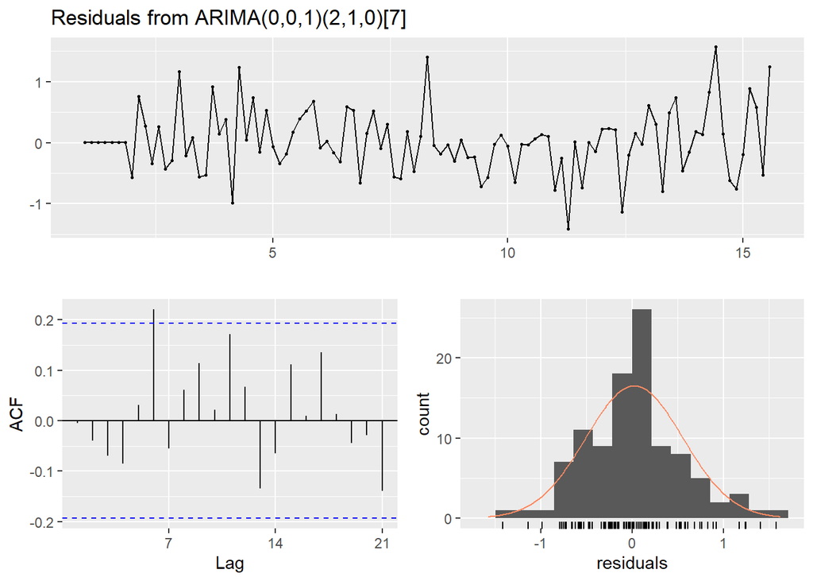

```
##
##  Ljung-Box test
##
## data:  Residuals from ARIMA(0,0,1)(2,1,0)[7]
## Q* = 15.975, df = 11, p-value = 0.142
##
## Model df: 3.   Total lags used: 14
```

```r
# Creat ethe arima model using teh box cox transforamtion
arima.bc <- auto.arima(lettuce.ts, lambda=boxcox)

#Checking the residuals.
checkresiduals(arima.bc)
```

### 5.4 Final checks

Before the quality of fit is investigated two final checks are performed:

```r
auto.arima(lettuce.ts, stepwise = FALSE,ic='aic')
```

```
## Series: lettuce.ts
## ARIMA(0,0,1)(2,1,0)[7]
##
## Coefficients:
##          ma1     sar1     sar2
##       0.2526  -0.6856  -0.3802
## s.e.  0.1279   0.1118   0.1171
##
## sigma^2 estimated as 881.2:  log likelihood=-462.31
## AIC=932.63   AICc=933.07   BIC=942.89
```

```r
#auto.arima(lettuce.ts, stepwise = FALSE,ic='bic')
```

2. Setting “trace = True” allows the information criteria scores from the various models to be observed and alternate selections to be made / evaluated.

```r
auto.arima(lettuce.ts,trace = TRUE, ic = 'aic')
```

```
##
##  ARIMA(2,0,2)(1,1,1)[7] with drift         : Inf
##  ARIMA(0,0,0)(0,1,0)[7] with drift         : 959.4565
##  ARIMA(1,0,0)(1,1,0)[7] with drift         : 942.2525
##  ARIMA(0,0,1)(0,1,1)[7] with drift         : Inf
##  ARIMA(0,0,0)(0,1,0)[7]                    : 957.4687
##  ARIMA(1,0,0)(0,1,0)[7] with drift         : 961.3931
##  ARIMA(1,0,0)(2,1,0)[7] with drift         : 935.2912
##  ARIMA(1,0,0)(2,1,1)[7] with drift         : Inf
##  ARIMA(1,0,0)(1,1,1)[7] with drift         : Inf
##  ARIMA(0,0,0)(2,1,0)[7] with drift         : 936.0419
##  ARIMA(2,0,0)(2,1,0)[7] with drift         : 935.904
##  ARIMA(1,0,1)(2,1,0)[7] with drift         : 935.8839
##  ARIMA(0,0,1)(2,1,0)[7] with drift         : 934.403
##  ARIMA(0,0,1)(1,1,0)[7] with drift         : 942.0057
##  ARIMA(0,0,1)(2,1,1)[7] with drift         : Inf
##  ARIMA(0,0,1)(1,1,1)[7] with drift         : Inf
##  ARIMA(0,0,2)(2,1,0)[7] with drift         : 935.7928
##  ARIMA(1,0,2)(2,1,0)[7] with drift         : Inf
##  ARIMA(0,0,1)(2,1,0)[7]                    : 932.6298
##  ARIMA(0,0,1)(1,1,0)[7]                    : 940.1299
##  ARIMA(0,0,1)(2,1,1)[7]                    : Inf
##  ARIMA(0,0,1)(1,1,1)[7]                    : Inf
##  ARIMA(0,0,0)(2,1,0)[7]                    : 934.2306
##  ARIMA(1,0,1)(2,1,0)[7]                    : 934.114
##  ARIMA(0,0,2)(2,1,0)[7]                    : 934.0247
##  ARIMA(1,0,0)(2,1,0)[7]                    : 933.5042
##  ARIMA(1,0,2)(2,1,0)[7]                    : Inf
##
##  Best model: ARIMA(0,0,1)(2,1,0)[7]
```

```
## Series: lettuce.ts
## ARIMA(0,0,1)(2,1,0)[7]
##
## Coefficients:
##          ma1     sar1     sar2
##       0.2526  -0.6856  -0.3802
## s.e.  0.1279   0.1118   0.1171
##
## sigma^2 estimated as 881.2:  log likelihood=-462.31
## AIC=932.63   AICc=933.07   BIC=942.89
```

```r
#auto.arima(lettuce.ts,trace = TRUE, ic = 'bic')
```

# 6 - Evaluation of model performance

To account for the step change in June a variety of test/train splits are evaluated, ranging from h=14 (2 weeks) to h=49 (7 weeks or 50% of the dataset)

```r
# Set the number of data points to be split off to form a test set.

#h=14
#h=21
#h=28
#h=35
#h=42
h=49

# Create the test and train datasets.
train <- subset(lettuce.ts, end = length(lettuce.ts) - h)
test <- subset(lettuce.ts, start = length(lettuce.ts) - h+1)

# Fit the training data using the ARIMA and ETS models previously determined
Arima.aic <- Arima(train, order= c(0,0,1), seasonal=c(2,1,0))
Arima.bic <- Arima(train, order= c(0,0,0), seasonal=c(2,1,0))
Arima.orig <- Arima(train, order= c(0,0,0), seasonal=c(1,1,0))
Arima.boxcox <- Arima(train, order= c(0,0,1), seasonal=c(2,1,0), lambda=boxcox)
ETS <- ets(train, model = "MNA")
```

The accuracy() function provides a range of measures against which the model performance can be assessed. Each accuracy measure is more or less punitive depending on the nature of the error. In the case of lettuce forecasts it is probably acceptable to have a minor errors, as any excess stock could be consumed the following day, while large errors could result in having to dispose of excess. Given this assumption the most appropriate measure is RMSE, which shows the ETS model consistently provides the best (smallest) results for the test data.

```r
# Produce forecasts for each model
fc.Arima.aic <- forecast(Arima.aic, h = h)
fc.Arima.bic <- forecast(Arima.bic, h = h)
fc.Arima.orig <- forecast(Arima.orig, h = h)
fc.Arima.boxcox <- forecast(Arima.boxcox, h = h)
fc.ETS <- forecast(ETS, h = h)


# Use accuracy function to find best model based on RMSE for each of the 5 models
print('ARIMA (AIC)')
```

```
## [1] "ARIMA (AIC)"
```

```r
accuracy(fc.Arima.aic, test)
```

```
##                      ME     RMSE      MAE        MPE     MAPE      MASE
## Training set   4.770805 26.32108 19.88719   1.515657 13.25650 0.7049005
## Test set     -18.156541 32.78735 24.85388 -18.553982 21.82486 0.8809444
##                     ACF1 Theil's U
## Training set -0.04033417        NA
## Test set      0.16828666 0.6071251
```

```r
print('ARIMA (BIC)')
```

```
## [1] "ARIMA (BIC)"
```

```r
accuracy(fc.Arima.bic, test)
```

```
##                      ME     RMSE      MAE        MPE     MAPE      MASE
## Training set   5.039386 26.42911 19.80180   1.674266 13.15198 0.7018739
## Test set     -18.194451 32.82478 24.87436 -18.626313 21.88744 0.8816705
##                    ACF1 Theil's U
## Training set 0.01319715        NA
## Test set     0.16834665 0.6084592
```

```r
print('ARIMA (Orig)')
```

```
## [1] "ARIMA (Orig)"
```

```r
accuracy(fc.Arima.orig, test)
```

```
##                      ME     RMSE      MAE         MPE     MAPE      MASE
## Training set   3.579627 27.89370 21.46533   0.7342999 14.52405 0.7608375
## Test set     -17.108757 33.58253 25.45042 -19.0845465 23.28159 0.9020890
##                     ACF1 Theil's U
## Training set -0.01000123        NA
## Test set      0.17312486 0.6564433
```

```r
print('ARIMA (BoxCox)')
```

```
## [1] "ARIMA (BoxCox)"
```

```r
accuracy(fc.Arima.boxcox, test)
```

```
##                      ME     RMSE      MAE        MPE     MAPE      MASE
## Training set   5.573811 26.96069 20.22649   2.053284 13.33889 0.7169267
## Test set     -16.873662 32.17583 24.00959 -17.659283 21.17208 0.8510186
##                   ACF1 Theil's U
## Training set 0.0169136        NA
## Test set     0.1613648 0.6032825
```

```r
print('ETS')
```

```
## [1] "ETS"
```

```r
accuracy(fc.ETS, test)
```

```
##                      ME     RMSE      MAE         MPE     MAPE      MASE
## Training set   3.797026 23.47393 19.59764  -0.7101673 13.96674 0.6946373
## Test set     -13.016443 29.73541 21.92465 -14.0506586 18.68712 0.7771180
##                    ACF1 Theil's U
## Training set 0.01580964        NA
## Test set     0.14548783 0.5394739
```

For reference the 3 best performing models have been overlaid in the plot below.

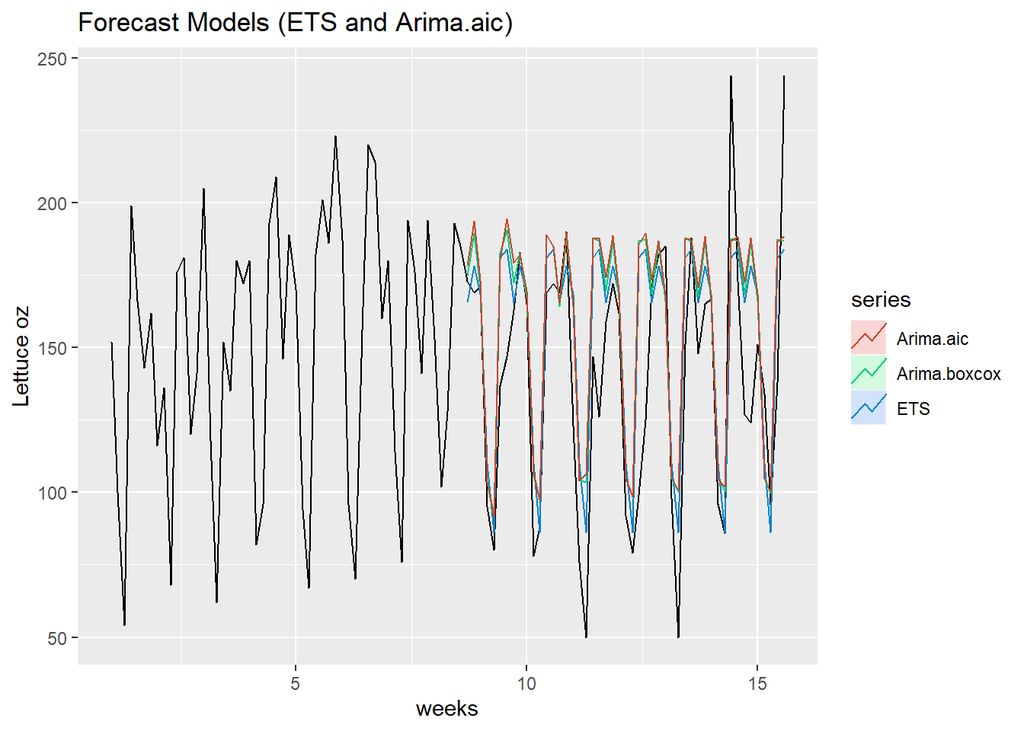

```r
autoplot(lettuce.ts) +
  ggtitle('Forecast Models (ETS and Arima.aic)')+
  xlab('weeks') +
  ylab('Lettuce oz') +
  autolayer(fc.ETS, series='ETS',PI=FALSE,size=0.5) +
  autolayer(fc.Arima.boxcox, series='Arima.boxcox',PI=FALSE,size=0.5) +
  autolayer(fc.Arima.aic, series='Arima.aic',PI=FALSE,size=0.5)
```

# 7 - Improving forecast accuracy

Despite performing best during the evaluation over all test / train split horizons it was observed in section 4.3 that the ETS model failed to capture the step change observed in the last 2 weeks of the data. To deliver the best forecasts a combination of objective and subjective information is required, ensuring additional explanatory factors are included where appropriate.

Though investigating the demand plots of the other stores (easily done by changing the store variable in section 2.3) it had been hoped to observe a consistent pattern that could provide some additional insight, however as can been seen in the plots below none was found as each exhibit a different profile.

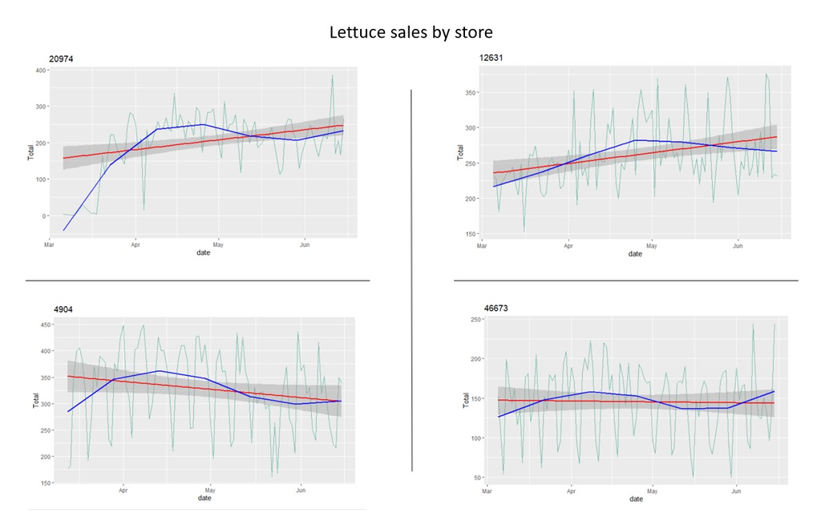

Charts of lettuce sales by store

### 7.1 - Inspecting the location

The next line of investigation was to explore the area around the store location using the provided zip code, Looking at the map below, 2 main attractions are revealed in the vicinity of the store.

- Golden Gate Field race club
- Beaches and Marinas

Investigating the race club calender (https://www.goldengatefields.com/full-calendar/) is inconclusive as it doesn’t extend back to 2015 however more recent years don’t reveal anything that could explain the observed fluctuations in demand.

Given the beach location one possible hypothesis is that sales could be correlated to the number of people visiting the beach. While beach attendance data is not available a correlation with the recorded temperature is a possibility. Temperature data is available from (https://www.timeanddate.com/weather/usa/berkeley/historic?month=3&year=2015) and has been extracted into a csv file for analysis.

[figure not shown]

Map of the local area

### 7.2 Modelling the impact of temprature

The following code block imports the csv file, prepares the data and converts it into a time series before plotting alongside the sales figures to allow comparison.

From the chart the strength of any correlation remains inconclusive although does warrant further investigation.

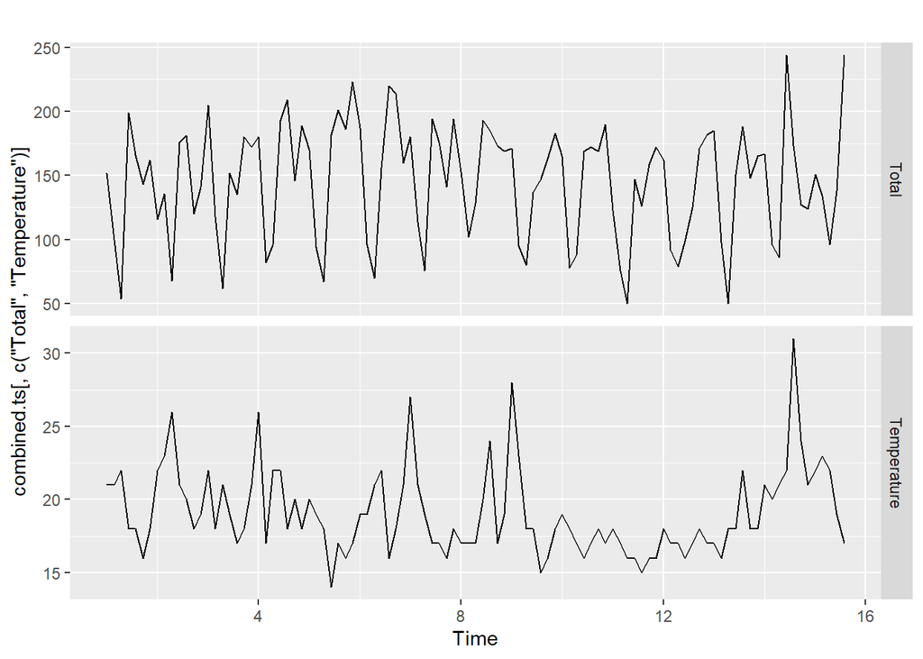

```r
# Load the data set "weather2.csv" file
temp <- read.csv('weather2.csv',header=TRUE)

# Join the temprature data with the sales file
combined <- cbind(summary,temp$temp)

#rename the columns to make them more friendly
names(combined)[names(combined) == "temp$temp"] <- "Temperature"

# Calculate the square of the temprature to account for non linear relationships
combined <- mutate(combined, Temp2 = Temperature^2)

# Convert to a time series setting the frequency to 7 for the number of days in a week
combined.ts <- ts(combined[,c("Total", "Temperature","Temp2")], frequency = 7)

#plot the series
autoplot(combined.ts[, c("Total", "Temperature")], facets = TRUE)
```

Creating an ARIMA model with an additional parameter $xreg$ allows a matrix of external regressors to be applied to the model. Here both the $temperature$ and $temperature^2$ have been used to allow for non linearity in the relationship.

Checking the residuals of the new function against those of the original auto.arima() model reveals the Ljung-Box p-value has reduced although the overall results remain satisfactory.

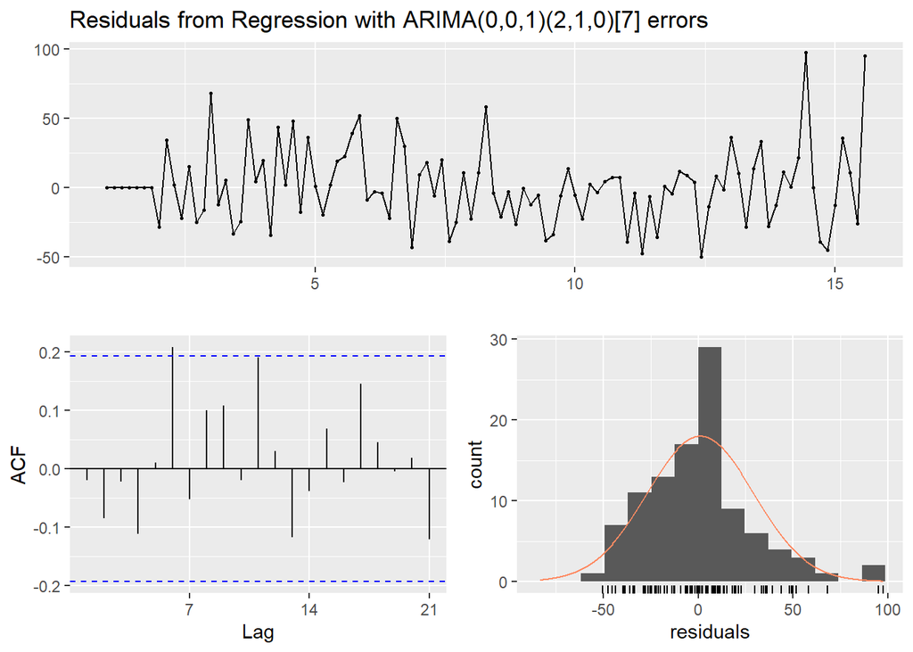

```
##
##  Ljung-Box test
##
## data:  Residuals from Regression with ARIMA(0,0,1)(2,1,0)[7] errors
## Q* = 16.103, df = 9, p-value = 0.06475
##
## Model df: 5.   Total lags used: 14
```

```r
# Fit ARIMA model with additonal xreg parameter
xreg = combined.ts[, c("Temperature","Temp2")]
Arima.temp <- Arima(combined.ts[, "Total"], xreg = xreg, order= c(0,0,1), seasonal=c(2,1,0))
checkresiduals(Arima.temp)
```

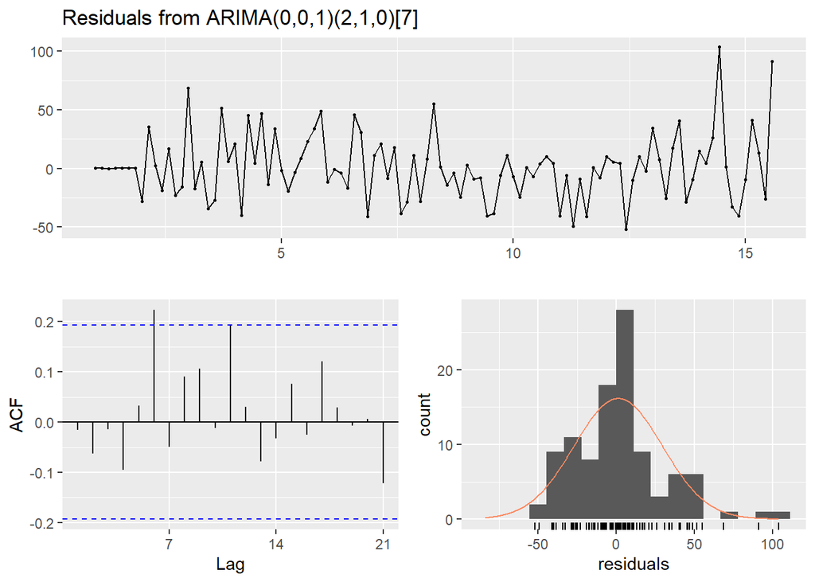

```
##
##  Ljung-Box test
##
## data:  Residuals from ARIMA(0,0,1)(2,1,0)[7]
## Q* = 15.067, df = 11, p-value = 0.1795
##
## Model df: 3.   Total lags used: 14
```

```r
# Display the original model for comparison
Arima.aic<-auto.arima(lettuce.ts,ic='aic')
checkresiduals(Arima.aic)
```

### 7.4 Fitting and testing the model

The performance of the new model is evaluated relative to the standard ARIMA model using the same approach to train and test datasets as before. When comparing the RMSE values for the test set the results are at best inconclusive and therefore the model including extra regressors is rejected

```r
#h=14
#h=21
#h=28
#h=35
#h=42
h=49

# Create the test and train datasets for the standard ARIMA model.
train <- subset(lettuce.ts, end = length(lettuce.ts) - h)
test <- subset(lettuce.ts, start = length(lettuce.ts) - h+1)
# Fit the training data using the standard ARIMA model
Arima.aic <- Arima(train, order= c(0,0,1), seasonal=c(2,1,0))

# Create the test and train dataset for the xreg arima model
train.temp <- subset(combined.ts, end = length(combined.ts)/3 - h)
test.temp <- subset(combined.ts, start = length(combined.ts)/3 - h+1)
# create the xreg matrix
xreg = train.temp[, c("Temperature","Temp2")]
# Fit ARIMA model with xreg
Arima.temp <- Arima(train.temp[, "Total"], xreg = xreg, order= c(0,0,1), seasonal=c(2,1,0))

# Produce forecasts for each model
fc.Arima.aic <- forecast(Arima.aic, h = h)
fc.Arima.temp <- forecast(Arima.temp, xreg = xreg)

# Use accuracy function to find best model based on RMSE for each of the 4 models
print('Standard ARIMA model')
```

```
## [1] "Standard ARIMA model"
```

```r
accuracy(fc.Arima.aic, test)
```

```
##                      ME     RMSE      MAE        MPE     MAPE      MASE
## Training set   4.770805 26.32108 19.88719   1.515657 13.25650 0.7049005
## Test set     -18.156541 32.78735 24.85388 -18.553982 21.82486 0.8809444
##                     ACF1 Theil's U
## Training set -0.04033417        NA
## Test set      0.16828666 0.6071251
```

```r
print('ARIMA model with xreg')
```

```
## [1] "ARIMA model with xreg"
```

```r
accuracy(fc.Arima.temp, test.temp[, "Total"])
```

```
##                     ME     RMSE      MAE        MPE     MAPE      MASE
## Training set   4.43657 25.99961 19.48051   1.375563 12.97896 0.6904857
## Test set     -17.35932 33.01697 25.02833 -18.262381 22.06721 0.8871278
##                     ACF1 Theil's U
## Training set -0.03661872        NA
## Test set      0.15896549 0.6223459
```

### 7.6 Selecting the prefered model

Despite all the efforts to enhance the model performance through including additional parameters and transformations, non proved reliable. While the ETS model performed well during the evaluation stage looking back at the historic data,it’s failure to capture the observed step change in June raise concerns regarding the quality of future forecasts.

The Arima model by contrast captured the seasonality well and was sensitive to the change in June.

The selected forecasting model to be used is therefore the $Arima (0,0,1)(2,1,0)[7]$ as shown below.

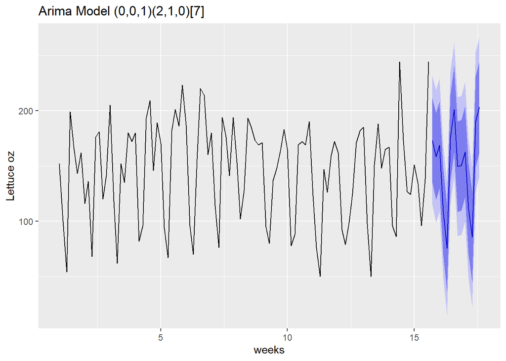

```r
# Create forecast
fc.Arima.aic <- forecast(Arima(lettuce.ts, order= c(0,0,1), seasonal=c(2,1,0)), h = 14)
#Plot
autoplot(lettuce.ts) +
  ggtitle('Arima Model (0,0,1)(2,1,0)[7]')+
  xlab('weeks') +
  ylab('Lettuce oz') +
  autolayer(fc.Arima.aic, PI=TRUE)
```

The following code block extracts the forecasts, with associated confidence intervals, as a CSV file.

```r
#Exportthe file
write.csv(fc.Arima.aic,"lettuce_forecast.csv", row.names = TRUE)
fc.Arima.aic
```

```
##          Point Forecast     Lo 80    Hi 80     Lo 95    Hi 95
## 15.71429      173.17182 135.12828 211.2154 114.98925 231.3544
## 15.85714      158.57302 119.33490 197.8111  98.56349 218.5826
## 16.00000      168.81293 129.57481 208.0511 108.80340 228.8225
## 16.14286      108.70714  69.46902 147.9453  48.69761 168.7167
## 16.28571       75.45758  36.21946 114.6957  15.44805 135.4671
## 16.42857      175.31844 136.08031 214.5566 115.30891 235.3280
## 16.57143      201.02426 161.78614 240.2624 141.01473 261.0338
## 16.71429      149.49960 108.47908 190.5201  86.76413 212.2351
## 16.85714      150.45658 109.32498 191.5882  87.55123 213.3619
## 17.00000      162.68300 121.55140 203.8146  99.77765 225.5883
## 17.14286      111.60153  70.46994 152.7331  48.69619 174.5069
## 17.28571       85.73993  44.60834 126.8715  22.83458 148.6453
## 17.42857      190.03110 148.89951 231.1627 127.12575 252.9364
## 17.57143      203.49644 162.36485 244.6280 140.59109 266.4018
```